# Exploring the BRFSS data

## Setup

### Load packages

```r
library(dplyr)
library(ggplot2)
library(knitr)
```

### Load data

```r
load("brfss2013.RData")
```

## Part 1: Data - Method, Bias, Scope

The Behavioral Risk Factor Surveillance System (BRFSS) is a surveillance system run by the Centers for Disease Control and Prevention that collects data from all participating US states and territoies by way of surveys, phone and in-person interviews. These surveys are run continuously through the year by contracted call centres, universities and employed interviewers to provide detailed information regarding risk-behaviours, chronic health conditions and the use of preventive services. The dataset is drawn from over 400,000 adult interviews each year and is conducted via Random Digit Dialing to both landlines and cell phones as well as in person at University campuses.

As an observational study with a randomised population the results are generalisable and corellation can be discussed, however as the subjects are not randomly assigened as in an experiment we cannot prove causality.

Though the survey is adminstered throughout the year and at different times in the day in order to catch the greatest variety of people there is inherent bias involved in collecting data via a phone sample. People that do not have a mobile or phone line, and people who don’t pick up the phone are examples of people missed by the survey. Furthermore, the misremembering of activites, and the over or under reporting of particular traights may produce skewed results.

## Part 2: Research questions

**Research question 1: Is income level associated with good mental health? The results would give a general idea of whether money actually can buy happiness.**

- Variable 1:income2 - Income Level
- Variable 2: menthlth - Number Of Days Mental Health Not Good
- Variable 3: sex - Respondent’s Sex

**Research question 2: Are people who vote more likely to exercise than those that don’t, and is there a difference between genders? As both are optional activities it would be interesting to see if those motivated enough to vote are also motivated enough to exercise.**

- Variable 1: scntvot1 - Did You Vote In The Last Presidential Election
- Variable 2: exerany2 - Exercise In Past 30 Days
- Variable 3: sex - Respondent’s Sex

**Research question 3: Is internet use associated with positive general health? The more time someone spends infront of a screen may prevent them from living a healthier lifestyle, or may be a positive as it may increases access to communication and entertaiment.**

- Variable 1: internet - Internet Use In The Past 30 Days
- Variable 2: genhlth - General Health

## Part 3: Exploratory data analysis

**Research question 1: Is income level associated with good mental health? The results would give a general idea of whether money actually can buy happiness.**

```r
q1 <- select(brfss2013, income2, menthlth, sex) %>%
  filter(!is.na(income2), !is.na(menthlth), menthlth < 40)

tab = with(q1, table(income2, sex, dnn = c("Income Level", "Sex as Percentages of Total Observations")))
round((tab/sum(tab)*100), 2)
```

```
##                    Sex as Percentages of Total Observations
## Income Level         Male Female
##   Less than $10,000  1.94   4.00
##   Less than $15,000  2.16   4.13
##   Less than $20,000  2.96   5.28
##   Less than $25,000  3.72   6.16
##   Less than $35,000  4.66   6.95
##   Less than $50,000  6.40   8.28
##   Less than $75,000  7.04   8.57
##   $75,000 or more   13.55  14.22
```

```r
population_summary_plot <- q1 %>%
  group_by(income2, sex) %>%
  summarise(mean_days = round(mean(menthlth), 2), sd_days = round(sd(menthlth), 2), n = n()) %>%
  arrange(desc(income2))

kable(population_summary_plot, col.names =
        c("Income Level", "Sex", "Mean Days of Bad Health", "Standard Deviation", "Observations"))
```

| Income Level | Sex | Mean Days of Bad Health | Standard Deviation | Observations |
| --- | --- | --- | --- | --- |
| $75,000 or more | Male | 1.50 | 4.91 | 56170 |
| $75,000 or more | Female | 2.34 | 5.84 | 58927 |
| Less than $75,000 | Male | 2.01 | 5.82 | 29180 |
| Less than $75,000 | Female | 2.87 | 6.69 | 35521 |
| Less than $50,000 | Male | 2.41 | 6.58 | 26515 |
| Less than $50,000 | Female | 3.21 | 7.22 | 34297 |
| Less than $35,000 | Male | 2.84 | 7.17 | 19328 |
| Less than $35,000 | Female | 3.70 | 7.90 | 28788 |
| Less than $25,000 | Male | 3.79 | 8.28 | 15422 |
| Less than $25,000 | Female | 4.50 | 8.77 | 25523 |
| Less than $20,000 | Male | 4.60 | 9.03 | 12254 |
| Less than $20,000 | Female | 5.09 | 9.27 | 21865 |
| Less than $15,000 | Male | 6.02 | 10.25 | 8939 |
| Less than $15,000 | Female | 6.50 | 10.39 | 17125 |
| Less than $10,000 | Male | 7.17 | 10.96 | 8020 |
| Less than $10,000 | Female | 8.13 | 11.37 | 16588 |

The summary statistics show that the largest cohort are those earning $75,000 or more with males and females represented fairly evenl, however make up a disproportiantly large representation in the lower income levels.

The average days reported are also notably different between genders. At each level women experience a higher number of poor mental health days.

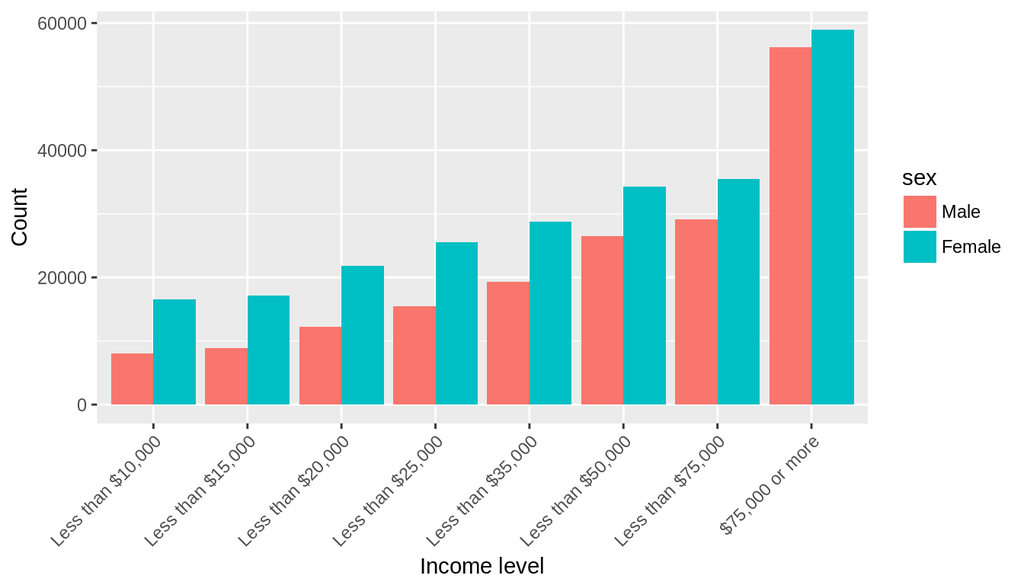

```r
ggplot(data = q1, aes(x = income2, fill = sex)) +
  geom_bar(position = position_dodge()) +
  theme(axis.text.x = element_text(angle = 45, hjust = 1)) +
  labs(x = "Income level", y = "Count")
```

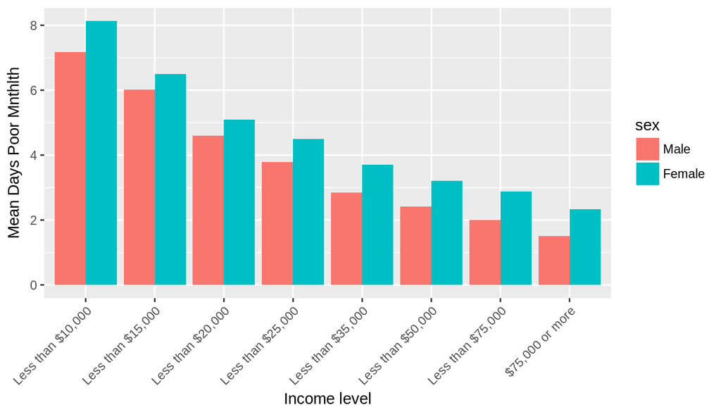

```r
ggplot(population_summary_plot, aes(x = income2, y = mean_days, fill = sex)) +
  geom_bar(stat = "identity", position = position_dodge()) +
  theme(axis.text.x = element_text(angle = 45, hjust = 1)) +
  labs(x = "Income level", y = "Mean Days Poor Mnthlth")
```

In short, there appears to be an association between income and overall mental health. Perhaps money can buy happiniess.

**Research question 2: Are people who vote more likely to exercise than those that don’t, and is there a difference between genders? As both are optional activities it would be interesting to see if those motivated enough to vote are also motivated enough to exercise.**

```r
q2 <- select(brfss2013, scntvot1, exerany2, sex) %>%
  filter(!is.na(scntvot1), !is.na(exerany2))

table(q2$scntvot1, q2$exerany2,dnn = c("Voted", "Exercised"))
```

```
##      Exercised
## Voted   Yes    No
##   Yes 39950 13238
##   No   7647  4354
```

Suprisingly the majority of respondents reported that they both exercised and voted. Turning the results into a categorical variable for further analysis:

```r
q2 <- q2 %>%
  mutate(status =
           case_when (exerany2 == 'Yes' & scntvot1 == "Yes" ~ "Voted and exercised",
             exerany2 == "No" & scntvot1 == "No" ~ "Didn't exercise or vote",
               exerany2 == "Yes" & scntvot1 == "No" ~ "Exercised but didn't vote",
                 exerany2 == "No" & scntvot1 == "Yes" ~ "Voted but didn't exercise"))
```

```r
summarytab <- q2 %>%
  group_by(status, sex) %>%
  summarise(count = n()) %>%
  mutate(rel_freq = round((count / sum(count)*100), 2))

kable(summarytab, col.names =
        c("Status", "Sex", "Observations", "Relative Frequency"))
```

| Status | Sex | Observations | Relative Frequency |
| --- | --- | --- | --- |
| Didn’t exercise or vote | Male | 1668 | 38.31 |
| Didn’t exercise or vote | Female | 2686 | 61.69 |
| Exercised but didn’t vote | Male | 3524 | 46.08 |
| Exercised but didn’t vote | Female | 4123 | 53.92 |
| Voted and exercised | Male | 15980 | 40.00 |
| Voted and exercised | Female | 23970 | 60.00 |
| Voted but didn’t exercise | Male | 4471 | 33.77 |
| Voted but didn’t exercise | Female | 8767 | 66.23 |

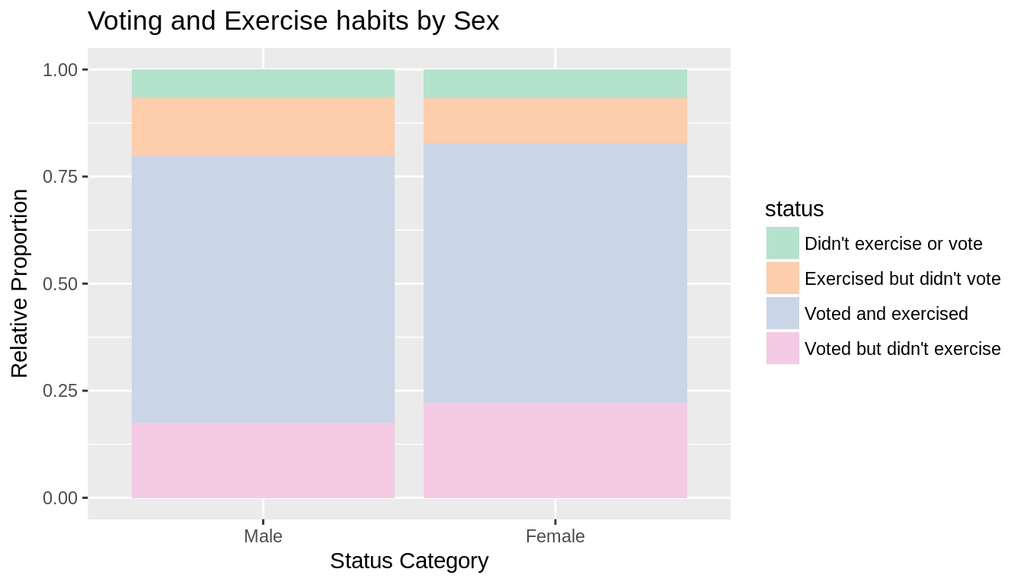

```r
ggplot(data = q2, aes(x = sex, fill = status)) +
  geom_bar(position = 'fill') +
  scale_fill_brewer(palette = "Pastel2") +
  labs(x = "Status Category", y = "Relative Proportion") +
  ggtitle("Voting and Exercise habits by Sex")
```

Given that voting and exercise are optional and require respondents may have lied and reported aspirational ideas instead of their actual activity. It does appear however that the majority of people vote and exercise, and of those that don’t men are more likely to exercise and not vote while women are more likely to vote and not exercise.

**Research question 3: Is internet use associated with positive general health? Is browsing possibly good for us**

The more time someone spends infront of a screen may prevent them from living a healthier lifestyle, or may be a positive as it may increases access to communication and entertaiment

Using the two variables internet and genhlth we can see what the general health habits of people are in association with their internet use.

```r
q3 <- select(brfss2013, genhlth, internet) %>%
  filter(!is.na(genhlth), !is.na(internet))

internet_summary_plot <- q3 %>%
  group_by(genhlth, internet) %>%
  summarise(count = n()) %>%
  mutate(rel_freq = round((count / sum(count)*100), 2))

kable(internet_summary_plot, col.names =
        c("Reported Health", "Internet Use", "Observations", "Relative Frequency"))
```

| Reported Health | Internet Use | Observations | Relative Frequency |
| --- | --- | --- | --- |
| Excellent | Yes | 74557 | 88.14 |
| Excellent | No | 10028 | 11.86 |
| Very good | Yes | 134192 | 85.08 |
| Very good | No | 23526 | 14.92 |
| Good | Yes | 107863 | 72.42 |
| Good | No | 41070 | 27.58 |
| Fair | Yes | 37120 | 56.22 |
| Fair | No | 28908 | 43.78 |
| Poor | Yes | 12748 | 46.13 |
| Poor | No | 14888 | 53.87 |

Rates of internet use increases for each level of general health, with the lowest usage rates amongst those that have poor general health.

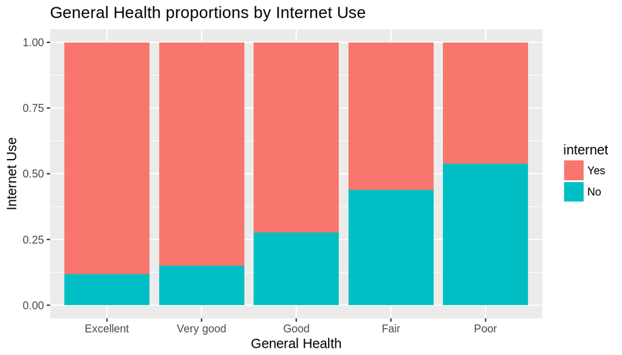

```r
ggplot(data = q3, aes(x = genhlth, fill = internet)) +
  geom_bar(position = 'fill') +
  labs(x = "General Health", y = "Internet Use") +
  ggtitle("General Health proportions by Internet Use")
```

Contrary to my hypothesis there appears to be an association between good general health and internet use. In fact a larger proportion of people with poor negative general health did not use the internet in the past 30 days. This is not likely a causal relationship and would in fact likely be brought about due to a confounding variable such as overall wealth or access to services.